# GGPlot For Visualization

Keman Xiang

## The Scenario

In this scenario, we are junior data analysts working for a hotel booking company. we have cleaned and manipulated our data, and gotten some initial insights we would like to share. Now, we are going to create some simple data visualizations with the `ggplot2` package. we will use basic `ggplot2` syntax and troubleshoot some common errors we might encounter.

## Step 1: Import our data

The data in this example is originally from the article Hotel Booking Demand Datasets (https://www.sciencedirect.com/science/article/pii/S2352340918315191), written by Nuno Antonio, Ana Almeida, and Luis Nunes for Data in Brief, Volume 22, February 2019.

The data was downloaded and cleaned by Thomas Mock and Antoine Bichat for #TidyTuesday during the week of February 11th, 2020 (https://github.com/rfordatascience/tidytuesday/blob/master/data/2020/2020-02-11/readme.md).

we can learn more about the dataset here: https://www.kaggle.com/jessemostipak/hotel-booking-demand

Import data from a .csv in the project folder called “hotel_bookings.csv” and save it as a data frame called `hotel_bookings`:

```r
hotel_bookings <- read.csv("hotel_bookings.csv")
```

## Step 2: Look at a sample of our data

Use the head() function to preview our data:

```r
head(hotel_bookings)
```

```
##          hotel is_canceled lead_time arrival_date_year arrival_date_month
## 1 Resort Hotel           0       342              2015               July
## 2 Resort Hotel           0       737              2015               July
## 3 Resort Hotel           0         7              2015               July
## 4 Resort Hotel           0        13              2015               July
## 5 Resort Hotel           0        14              2015               July
## 6 Resort Hotel           0        14              2015               July
##   arrival_date_week_number arrival_date_day_of_month stays_in_weekend_nights
## 1                       27                         1                       0
## 2                       27                         1                       0
## 3                       27                         1                       0
## 4                       27                         1                       0
## 5                       27                         1                       0
## 6                       27                         1                       0
##   stays_in_week_nights adults children babies meal country market_segment
```

[output cut: 41 more lines]

We can also use colnames() to get the names of all the columns in our data set.

```r
colnames(hotel_bookings)
```

```
##  [1] "hotel"                          "is_canceled"
##  [3] "lead_time"                      "arrival_date_year"
##  [5] "arrival_date_month"             "arrival_date_week_number"
##  [7] "arrival_date_day_of_month"      "stays_in_weekend_nights"
##  [9] "stays_in_week_nights"           "adults"
## [11] "children"                       "babies"
## [13] "meal"                           "country"
## [15] "market_segment"                 "distribution_channel"
## [17] "is_repeated_guest"              "previous_cancellations"
## [19] "previous_bookings_not_canceled" "reserved_room_type"
## [21] "assigned_room_type"             "booking_changes"
## [23] "deposit_type"                   "agent"
## [25] "company"                        "days_in_waiting_list"
## [27] "customer_type"                  "adr"
## [29] "required_car_parking_spaces"    "total_of_special_requests"
## [31] "reservation_status"             "reservation_status_date"
```

## Step 3: Install and load the ‘ggplot2’ package

If we haven’t already installed and loaded the `ggplot2` package, we will need to do that before we can use the `ggplot()` function.

## Step 4: Begin creating a plot

We can use `ggplot2` to determine if people with children book hotel rooms in advance.

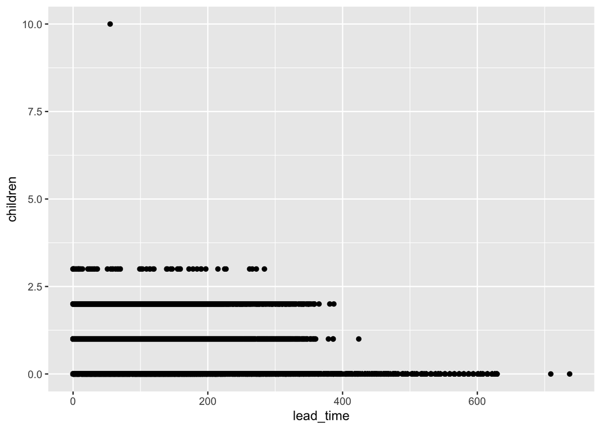

```r
ggplot(data = hotel_bookings) +
  geom_point(mapping = aes(x = lead_time, y = children))
```

On the x-axis, the plot shows how far in advance a booking is made, with the bookings furthest to the right happening the most in advance. On the y-axis it shows how many children there are in a party.

## Step 5: Try mapping ‘stays_in_weekend_nights’ on the x-axis

Try mapping ‘stays_in_weekend_nights’ on the x-axis and ‘children’ on the y-axis

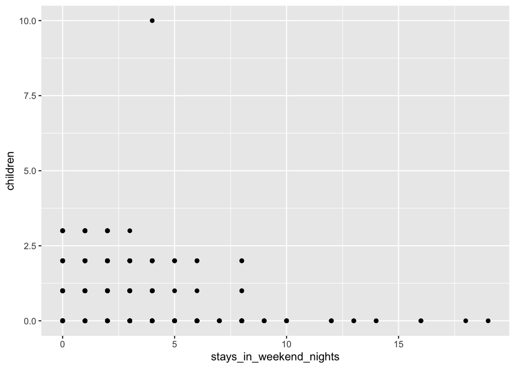

```r
ggplot(data = hotel_bookings) +
 geom_point(mapping = aes(x = stays_in_weekend_nights, y = children))
```

We now have a scatterplot with ‘stays_in_weekend_nights’ on the x-axis and ‘children’ on the y-axis.

## Activity Wrap Up

The `ggplot2` package allows we to quickly create data visualizations that can answer questions and give we insights about our data.